# Emissions Scenarios

Climate models require assumptions about future atmospheric greenhouse gas concentrations and other factors that affect the climate system. These assumptions are represented through scenarios: structured and internally coherent descriptions of plausible futures, rather than predictions of what will occur.

Scenarios are informed by possible socioeconomic developments, including changes in population, education, economic activity, technology, energy demand and sources, land use, urbanization, inequality, governance, and the degree of political commitment to reducing emissions. These factors influence future emissions, their accumulation in the atmosphere, society’s capacity to mitigate climate change, and its ability to adapt to climate impacts.

Future socioeconomic development and emissions are inherently uncertain. Scenario uncertainty is therefore an important component of the overall uncertainty in climate projections, particularly over longer time horizons. See Uncertainty and Confidence for the relationship between scenario uncertainty, model uncertainty and internal climate variability, and Climate-Model Ensembles for how these dimensions are represented in ensembles.

### Shared Socioeconomic Pathways (SSPs)

Two scenario frameworks have been used in recent CMIP experiments. Representative Concentration Pathways ([RCPs](https://climatedata.ca/interactive/emissions-scenarios-rcps)) were used in the fifth phase of CMIP (CMIP5) and informed the IPCC Fifth Assessment Report. Shared Socioeconomic Pathways ([SSPs](https://climatedata.ca/resource/understanding-shared-socio-economic-pathways-ssps)), combined with specified levels of radiative forcing, were used in CMIP6 and informed the IPCC Sixth Assessment Report.

The SSPs describe alternative socioeconomic pathways along which society might develop. They are paired with forcing levels—such as 2.6, 4.5, 7.0, or 8.5 watts per square metre (W/m²) by 2100—to create scenarios used in climate-model experiments. Common CMIP6 scenarios include SSP1-2.6, SSP2-4.5, SSP3-7.0, and SSP5-8.5.

For example, SSP2-4.5 combines a “middle-of-the-road” socioeconomic pathway, in which historical social, economic, and technological trends broadly continue, with a radiative forcing level of approximately 4.5 W/m² by 2100. In general, scenarios associated with higher greenhouse gas concentrations produce greater warming. However, individual models can project different amounts and patterns of change under the same scenario because their representations of the climate system and their sensitivity to forcing differ.

RCP and SSP scenarios with similar forcing levels can produce broadly comparable large-scale climate signals, but they are not interchangeable in every respect. Differences in their underlying socioeconomic assumptions, emissions trajectories, land-use changes, and climate-model generations may be relevant to a particular application. When suitable CMIP6 projections are available, they will generally provide a more current basis for assessment than CMIP5. Nevertheless, CMIP5 projections may remain appropriate when consistency with earlier work is important, when relevant impact models were developed using CMIP5 data, or when CMIP6 data do not meet the needs of the assessment.

The emissions scenarios proposed for the upcoming CMIP7 [ScenariodMIP](https://wcrp-cmip.org/mips/scenariomip/) simulations are outlined in Van Vuuren *et al.* (2026).

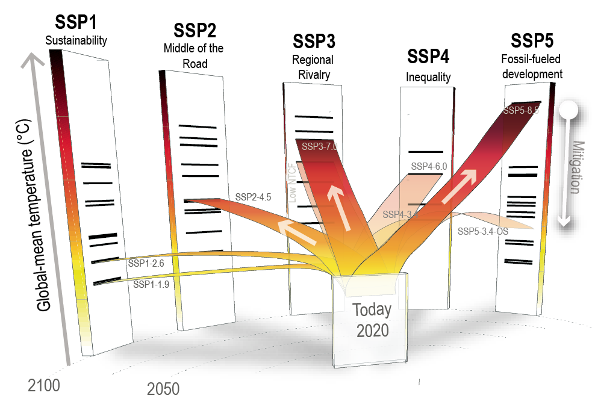

The five Shared Socioeconomic Pathways (SSPs) describe contrasting ways in which society could develop over the 21st century, from sustainability (SSP1) to fossil-fuelled development (SSP5). These socioeconomic pathways can be combined with different greenhouse gas concentration trajectories and radiative forcing levels to form scenarios such as SSP1-2.6, SSP2-4.5, SSP3-7.0, and SSP5-8.5. The colours indicate projected global warming, from lower warming in yellow to higher warming in red. Multiple climate outcomes may be consistent with a given socioeconomic pathway, depending on mitigation efforts. Source: Chen *et al.* (2021), Cross-Chapter Box 1.4, Figure 1.

### Selecting scenarios for an assessment

Scenario selection should reflect the decision being examined, the assessment horizon, the consequences of being wrong, and the organization’s tolerance for risk. Scenarios should not be treated as forecasts with probabilities assigned to them unless a defensible probabilistic framework has been established. Rather than selecting a single scenario as the expected future, practitioners should generally explore a range of plausible outcomes and evaluate their implications for the energy system or asset under consideration.

The time horizon is particularly important. Over approximately the next two to three decades, projected differences among emissions scenarios are smaller than later in the century because the scenarios begin from similar recent conditions and the climate system responds gradually to changes in forcing. During this near-term period, natural variability and differences among models may contribute substantially to the range of projections. Nevertheless, considering at least two scenarios — typically a low-to-moderate-emissions pathway and a high-emissions pathway — is good practice, particularly for decisions involving long-lived assets.

Beyond mid-century, scenario trajectories increasingly diverge, and projected changes under lower- and higher-emissions pathways can differ substantially. Assessments of infrastructure, investments, or plans with long lifetimes should therefore examine multiple scenarios. Where potential consequences are severe or difficult to reverse, a precautionary or stress-testing approach may also warrant examining a high-emissions scenario and the upper end of the range of corresponding climate-model outcomes.

According to Working Group III of the IPCC’s sixth assessement report, SSP5-8.5 (like RCP8.5) does not represent a typical business-as-usual scenario and is currently considered unlikely. It is useful only as a high-risk scenario, representative of the upper limit of “no climate policy” scenarios. SSP5-8.5 may be relevant in the context of unlikely hazards with catastrophic consequences, or as an analogue for a post-2100 climate.

For additional information on emissions scenarios, we recommend visiting [ClimateData.ca](https://climatedata.ca/resource/understanding-shared-socio-economic-pathways-ssps/).

## References

Chen, D., Rojas, M., Samset, B. H., … Tréguier, A.-M. (2021). [Framing, context, and methods](https://doi.org/10.1017/9781009157896.003). In V. Masson-Delmotte, P. Zhai, A. Pirani, … B. Zhou, eds., *Climate change 2021: The physical science basis. Contribution of working group i to the sixth assessment report of the intergovernmental panel on climate change*, Book Section, Cambridge, UK; New York, NY, USA: Cambridge University Press, pp. 147–286.

Van Vuuren, D. P., O’Neill, B. C., Tebaldi, C., … Ziehn, T. (2026). [The scenario model intercomparison project for CMIP7 (ScenarioMIP-CMIP7)](https://doi.org/10.5194/gmd-19-2627-2026). *Geoscientific Model Development*, **19**(7), 2627–2656.